# California Food Affordability

#### R analysis by Dan Spector

## This is a dataset from California Health and Human Services about food affordability in Californian female-headed households with children.

From the summary:

“This table contains data on the average cost of a market basket of nutritious food items relative to income for female-headed households with children, for California, its regions, counties, and cities/towns. The ratio uses data from the U.S. Department of Agriculture and the U.S. Census Bureau.”

Link to the data: https://data.chhs.ca.gov/dataset/food-affordability-2006-2010

First, I import the data and load tidyverse. I’m reading the dataset from online but I’ve attached a local copy in the folder. I’m also installing a package which will be helpful later on for labeling the scatterplot.

```r
food_data <- read.csv("https://data.chhs.ca.gov/dataset/0114f5bb-4975-419d-95d9-5f0179a8de06/resource/916e2a2e-383b-4af5-9f5b-310500961cb5/download/food-affordability-2006-2010.csv")
library(tidyverse)
install.packages("ggrepel")
library(ggrepel)
str(food_data)
```

```
'data.frame':   14364 obs. of  23 variables:
 $ ind_id                  : int  757 757 757 757 757 757 757 757 757 757 ...
 $ ind_definition          : Factor w/ 1 level "Food affordability for female-headed household with children under 18 years": 1 1 1 1 1 1 1 1 1 1 ...
 $ reportyear              : Factor w/ 1 level "2006-2010": 1 1 1 1 1 1 1 1 1 1 ...
 $ race_eth_code           : int  1 2 3 4 5 6 7 8 9 1 ...
 $ race_eth_name           : Factor w/ 9 levels "AfricanAm","AIAN",..: 2 3 1 4 6 9 5 7 8 2 ...
 $ geotype                 : Factor w/ 4 levels "CA","CO","PL",..: 1 1 1 1 1 1 1 1 1 2 ...
 $ geotypevalue            : int  6 6 6 6 6 6 6 6 6 6001 ...
 $ geoname                 : Factor w/ 1581 levels "Acalanes Ridge CDP",..: 186 186 186 186 186 186 186 186 186 11 ...
 $ county_name             : Factor w/ 59 levels "","Alameda","Alpine",..: 1 1 1 1 1 1 1 1 1 2 ...
 $ county_fips             : int  NA NA NA NA NA NA NA NA NA 6001 ...
 $ region_name             : Factor w/ 15 levels "Bay Area","Butte",..: 3 3 3 3 3 3 3 3 3 1 ...
 $ region_code             : int  NA NA NA NA NA NA NA NA NA 1 ...
 $ cost_yr                 : num  7508 7508 7508 7508 7508 ...
 $ median_income           : num  23777 38508 26192 22858 36737 ...
 $ affordability_ratio     : num  0.316 0.195 0.287 0.328 0.204 ...
 $ LL95_affordability_ratio: num  0.232 0.183 0.28 0.323 0.174 ...
 $ UL95_affordability_ratio: num  0.4 0.207 0.294 0.334 0.235 ...
 $ se_food_afford          : num  0.04299 0.00608 0.00357 0.00298 0.01562 ...
 $ rse_food_afford         : num  13.614 3.118 1.246 0.907 7.643 ...
 $ CA_decile               : int  NA NA NA NA NA NA NA NA NA NA ...
 $ CA_RR                   : num  1.185 0.732 1.076 1.233 0.767 ...
 $ ave_fam_size            : num  3.34 3.34 3.34 3.34 3.34 3.34 3.34 3.34 3.34 3.21 ...
 $ version                 : Factor w/ 1 level "04/12/2013 04:33:00 AM": 1 1 1 1 1 1 1 1 1 1 ...
```

I tried really hard to filter using vanilla R and I just couldn’t figure it out. So I’m using filter() from dplyr (tidyverse). I’m filtering out the first rows in the dataset, which give me the average results for the whole state of California. I’m also filtering out the “Total” value in the race/ethncity variable, because that is an average as well.

```r
filtered_data <- filter(food_data, geoname != "California" & race_eth_name != "Total")
```

Now, I will find some summary statistics for various variables. I don’t know how to write functions in R so this will be very inefficient :(

## Summary Statistics of Race/Ethnicities

First, I filter for the data of four races/ethnicities. Then, I calculate the mean of each race’s median income and put it in a variable. Then, I make a vector with the labels. Then I combine both vectors into a dataframe.

```r
AfricanAm <- filter(filtered_data, race_eth_name == "AfricanAm")
Asian <- filter(filtered_data, race_eth_name == "Asian")
White <- filter(filtered_data, race_eth_name == "White")
Latino <- filter(filtered_data, race_eth_name == "Latino")
AfricanAmMean <- mean(AfricanAm$median_income, na.rm = TRUE)
AsianMean <- mean(Asian$median_income, na.rm = TRUE)
WhiteMean <- mean(White$median_income, na.rm = TRUE)
LatinoMean <- mean(Latino$median_income, na.rm = TRUE)
meansbyRace <- c(AfricanAmMean, AsianMean, WhiteMean, LatinoMean)
labels <- c("African-American", "Asian", "White", "Latino")
labeledMeans <- data.frame(labels, meansbyRace)
labeledMeans <- data.frame(Race_Ethnicity = labels, Average_Median_Household_Income = meansbyRace)
```

Then, I draw the chart.

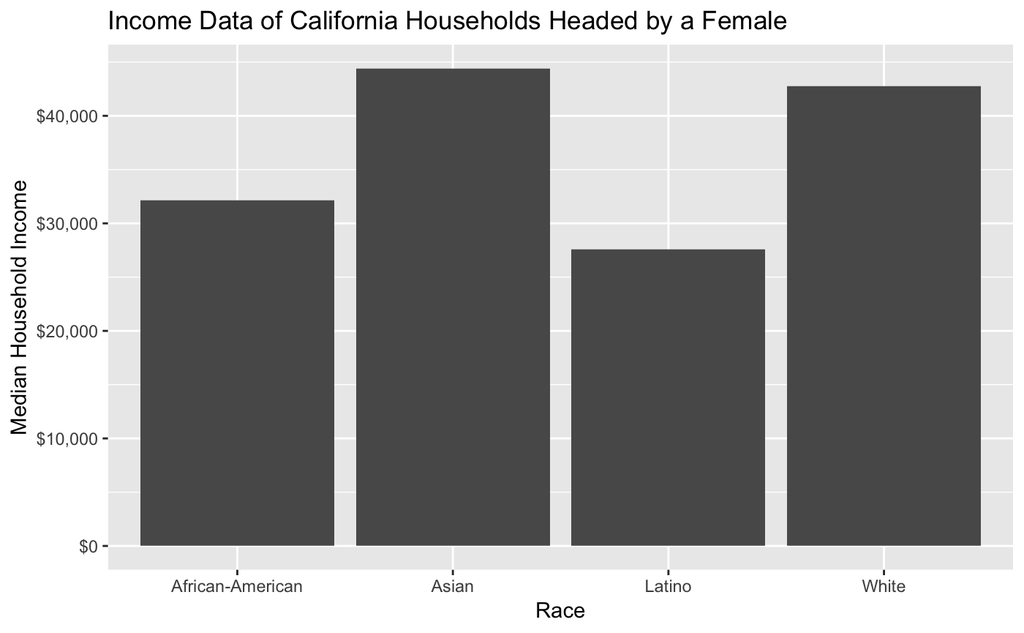

```r
ggplot() +
  geom_col(data=labeledMeans, aes(x=Race_Ethnicity, y=Average_Median_Household_Income)) +
  scale_y_continuous(labels = scales::dollar) +
  xlab("Race") +
  ylab("Median Household Income") +
  ggtitle("Income Data of California Households Headed by a Female")
```

Aggregate: Dietmar showed me this in class.

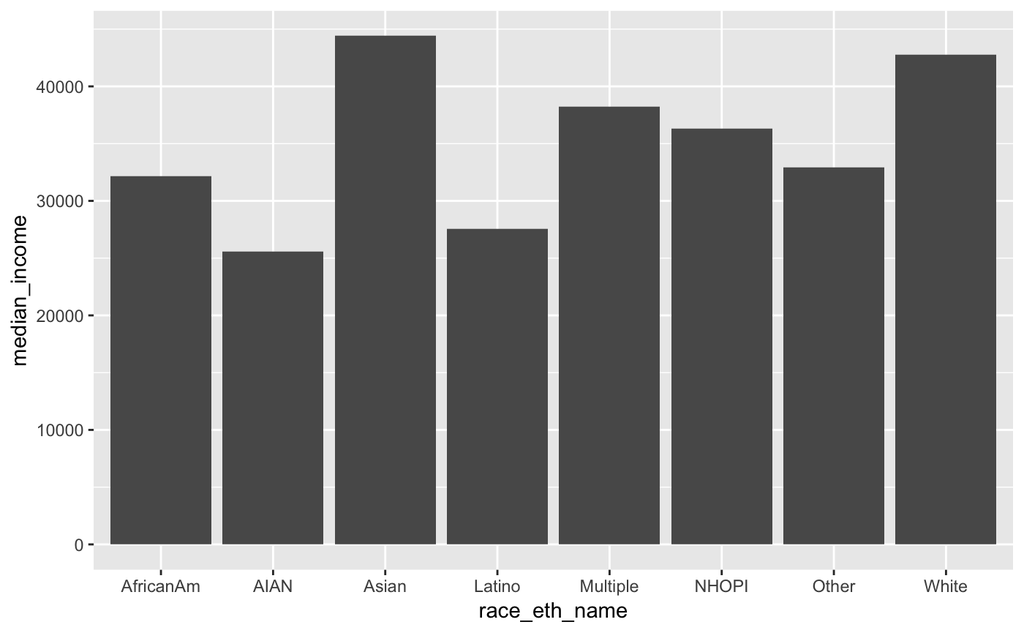

```r
incomebyRace <- aggregate(median_income ~ race_eth_name, data = filtered_data, FUN = mean)
ggplot(incomebyRace, aes(x= race_eth_name, y= median_income)) + geom_bar(stat = "identity")
```

## Mean Affordability Ratio by City

Now, I want to find the mean affordability ratio for various cities, and plot them on a scatterplot. The lower the affordability ratio, the lower the percentage of income goes to food. The higher the affordability ratio, the higher the percentage of income goes to food.

The California cities I am interested in are Carmel, San Diego, San Francisco, Mountain View, San Luis Obispo, Los Angeles, and Malibu. I find the mean affordability ratio for each city and put it in a dataframe with labels.

```r
Carmel <- filter(filtered_data, geoname == "Carmel-by-the-Sea city")
SD <-  filter(filtered_data, geoname == "San Diego")
SF <-  filter(filtered_data, geoname == "San Francisco")
Mountain_View <-  filter(filtered_data, geoname == "Mountain View city")
Slo <-  filter(filtered_data, geoname == "San Luis Obispo")
LA <-  filter(filtered_data, geoname == "Los Angeles")
Malibu <-  filter(filtered_data, geoname == "Malibu city")
carmelMean <- mean(Carmel$affordability_ratio, na.rm=TRUE)
sdMean <- mean(SD$affordability_ratio, na.rm=TRUE)
sfMean <- mean(SF$affordability_ratio, na.rm=TRUE)
mountainViewMean <- mean(Mountain_View$affordability_ratio, na.rm=TRUE)
sloMean <- mean(Slo$affordability_ratio, na.rm=TRUE)
laMean <- mean(LA$affordability_ratio, na.rm=TRUE)
malibuMean <- mean(Malibu$affordability_ratio, na.rm=TRUE)
cityMeans <- c(carmelMean, sdMean, sfMean, mountainViewMean, sloMean, laMean, malibuMean)
cityLabels <-c("Carmel", "San Diego", "San Francisco", "Mountain View", "San Luis Obispo", "Los Angeles", "Malibu")
population <- c(3891, 1470000, 870887, 80447, 47536, 3976000, 12879)
city_df <- data.frame(cityLabels, cityMeans, population)
```

Then, I draw the scatterplot. X is the mean affordability ratio and Y is the population, which I entered into a vector manually.

[figure not shown]

```r
ggplot(city_df, aes(x=cityMeans, y=population)) +
  geom_point() +
  scale_y_continuous(labels = scales::comma, limits = c(0, 4000000)) +
  geom_smooth(method = "lm", se = FALSE) +
  geom_label_repel(label=cityLabels, size = 3.5) +
  xlab("Mean Affordability Ratio") +
  ylab("Population") +
  ggtitle("How Much Income Goes To Food In California Cities?")
```

According to this graph, affordability ratio is correlated with population. In other words, as population increases, more income tends to go to food. However, this correlation is definitely misleading because this sample is not representative of California as a whole. The smaller populated cities on this graph (Carmel, Malibu, Mountain View) are relatively wealthy, so it would make sense that less income goes to food in these places. Not all small towns in California are wealthy!

## Distribution, Normality, and Z Scores

First I will plot two simple histograms comparing the distribution of African American and Asian incomes. To refresh, this is the distribution of median household incomes of female-headed households in all California cities and towns.

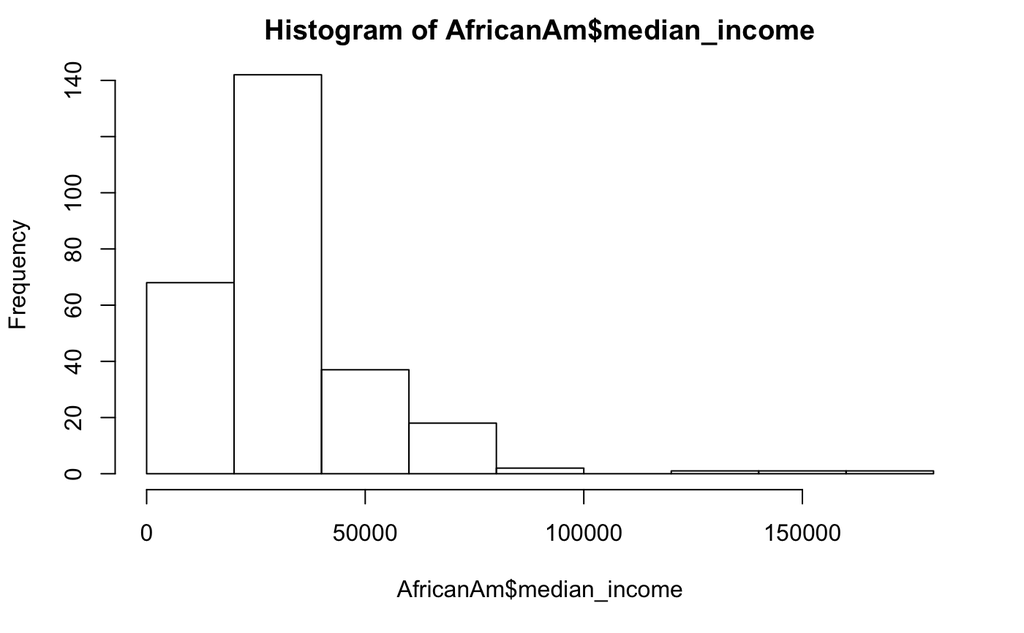

```r
hist(AfricanAm$median_income)
```

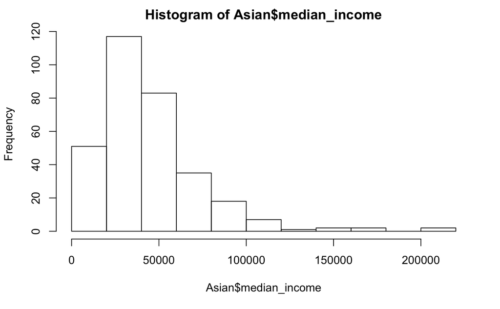

```r
hist(Asian$median_income)
```

I already have the mean of the median income distributions from the previous analysis. However, I still need to calculate the standard deviations. Then, I can calculate the z-scores.

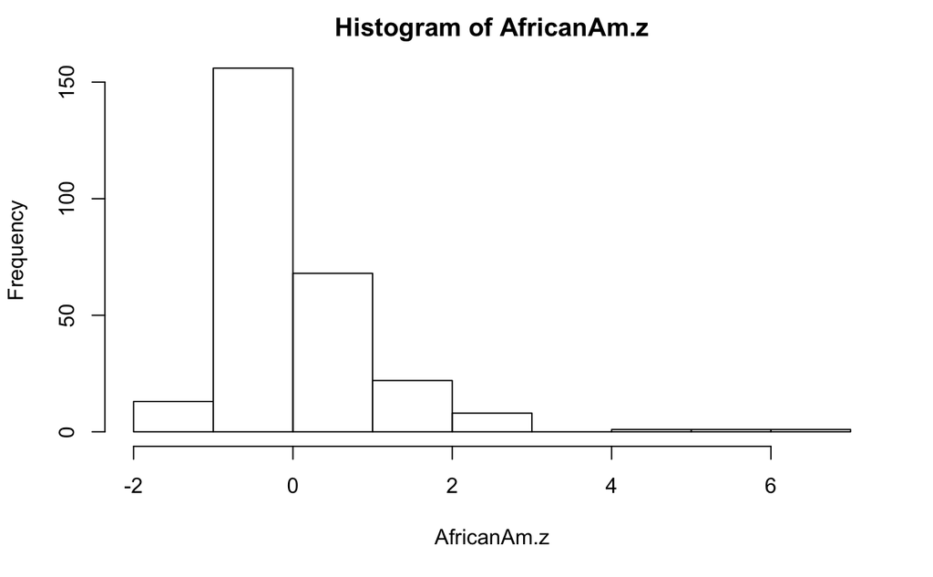

```r
AfricanAm.sd <- sd(AfricanAm$median_income, na.rm = TRUE)
Asian.sd <- sd(Asian$median_income, na.rm = TRUE)
AfricanAm.z <- (AfricanAm$median_income - AfricanAmMean) / AfricanAm.sd
Asian.z <- (Asian$median_income - AsianMean) / Asian.sd
hist(AfricanAm.z)
```

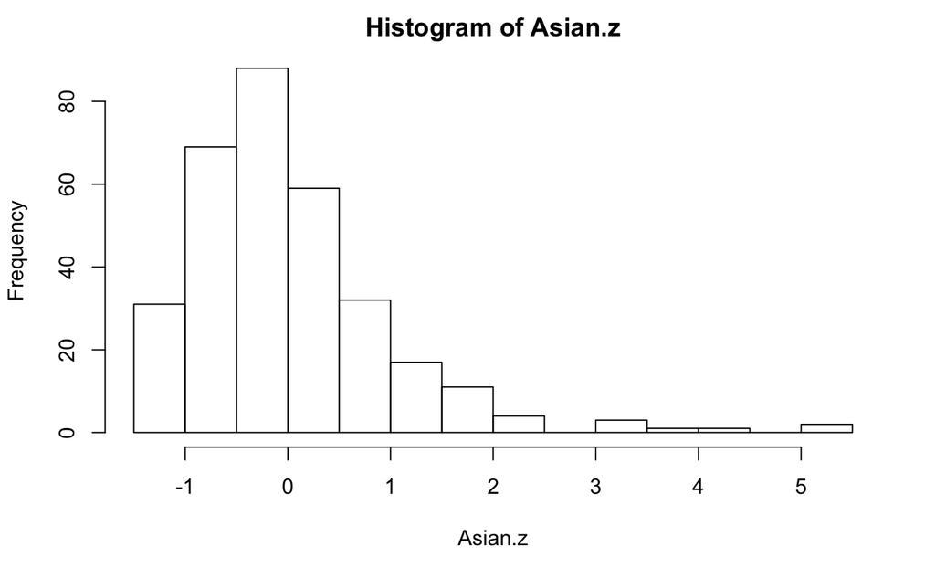

```r
hist(Asian.z)
```

Both of these distributions are positively skewed. In other words, the majority of the income distribution for both groups is on the lower end, and there is a large tail to the right. That means the mean will be larger than the median. In general, income in the U.S. tends to be positively skewed in this capacity. There are simply a much greater number of lower wage earners than higher wage earners.

Now, let’s look at the qqplots and test for normality.

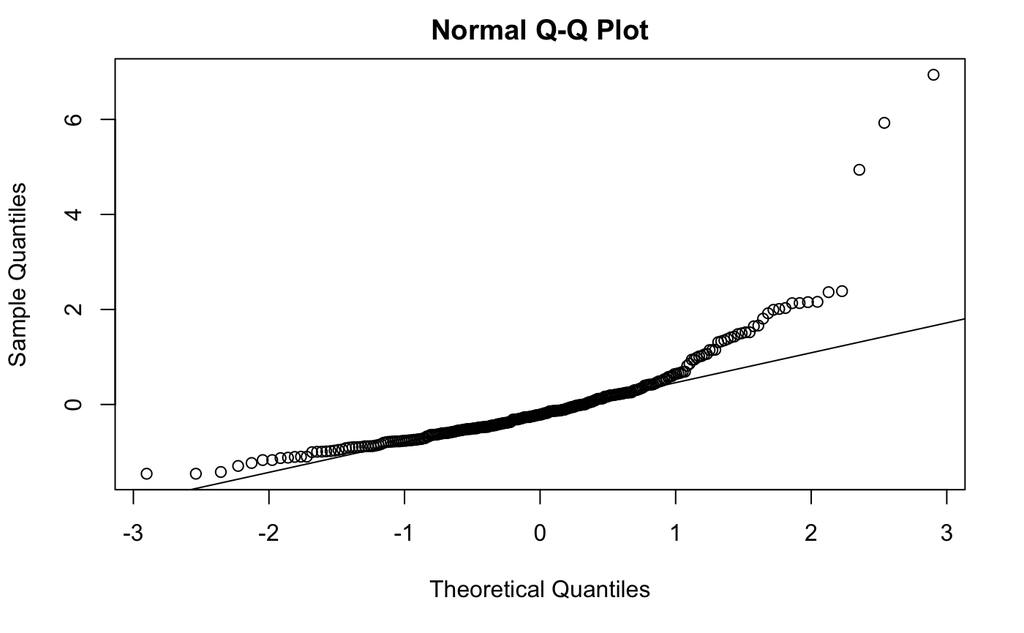

```r
qqnorm(AfricanAm.z)
qqline(AfricanAm.z)
```

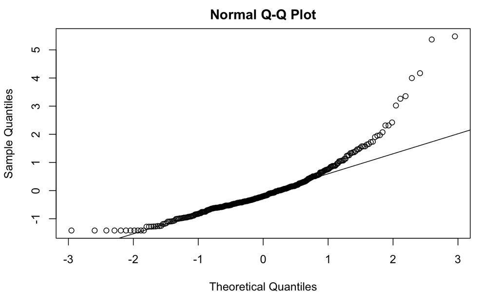

```r
qqnorm(Asian.z)
qqline(Asian.z)
```

```r
shapiro.test(AfricanAm.z)
```

```
    Shapiro-Wilk normality test

data:  AfricanAm.z
W = 0.7813, p-value < 2.2e-16
```

```r
shapiro.test(Asian.z)
```

```
    Shapiro-Wilk normality test

data:  Asian.z
W = 0.86098, p-value = 2.8e-16
```

In The Shapiro-Wilk normality test, the null hypothesis is that the distribution is normal: http://www.sthda.com/english/wiki/normality-test-in-r

Therefore, because the p-values are below .05, the result is significant and we can reject the null hypothesis. Therefore, these distributions are not normal.

### Now, let’s examine the distribution of cost of food per year amongst all female-headed families in California:

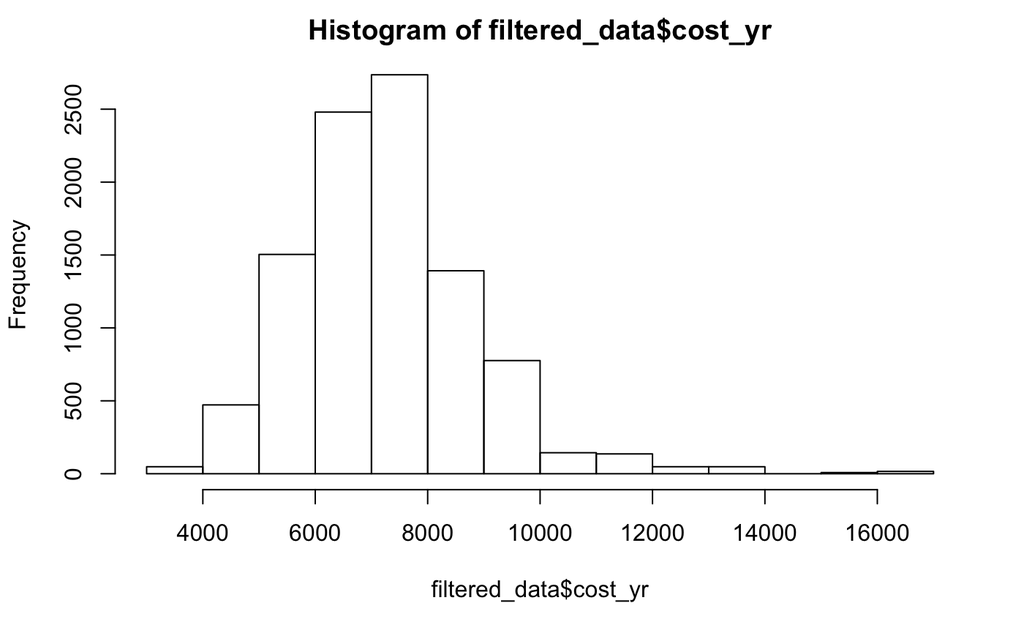

```r
hist(filtered_data$cost_yr)
```

Could this be another positively skewed distribution?

Now for the z-scores:

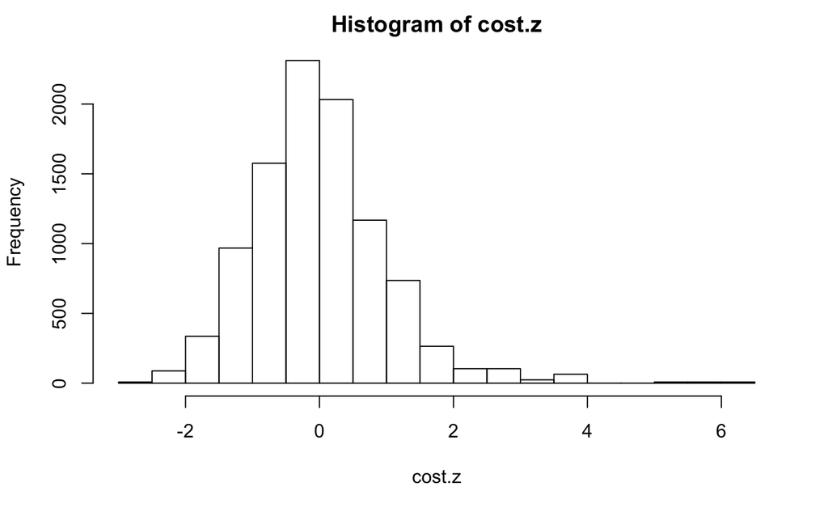

```r
cost <- (filtered_data$cost_yr)
cost.mean <- mean(cost, na.rm = TRUE)
cost.sd <- sd(cost, na.rm = TRUE)
cost.z <- (cost - cost.mean) / cost.sd
hist(cost.z)
```

Is this a normal distribution with very high outliers or a positively skewed distribution?

```r
qqnorm(cost.z)
qqline(cost.z)

shapiro.test(cost.z)
```

[output not shown]

Since the Shapiro test doesn’t work with more than 5000 values, I will use another normality test called the Anderson-Darling test.

```r
install.packages("nortest")
library(nortest)
ad.test(cost.z)
```

```
    Anderson-Darling normality test

data:  cost.z
A = 59.804, p-value < 2.2e-16
```

Again, the null hypothesis is normality. Since the p-value is <.05, the null hypothesis is rejected. This is not a normal distribution. As seen in the first histogram, there is a small minority of families with a very high food cost per year, around $15,000 - $16,000, which skews the data in the positive direction.